# BIO1007A

Andrew Planting

2023-01-31

## Final Assignment

Overview:

I want to recreate Figures 1 and 2 from my final lab in BIO 140 (Eco/evo). Figure 1 evalutes the mean densities of Ephemeroptera, Plecoptera, and Trichoptera between 2009 and 2022 in Middlebury and New Haven stream research sites (Middlebury,VT). Figure 2 evaluates the effects of winter precipitation on the mean density of Ephemeroptera and Trichoptera (also found in the Middlebury and New Haven stream research sitesbetween 2009 and and 2022. We studied these data as understanding fluctuations in insect density populations is useful when determining overall freshwater stream ecosystem health.

General steps to recreate the figures below:

1. Arrange data in a way that will make it easily plotable (i.e., condense separate columns with the same information into one column… see troubleshooting)
2. Convert Xcel file into .csv file so it can be loaded by R
3. Load Xcel file into R using read.table()
4. Load desired plot using library(ggplot)
5. Arrange ggplot as desired (follow general annotations below)

**Original Figure 1:**

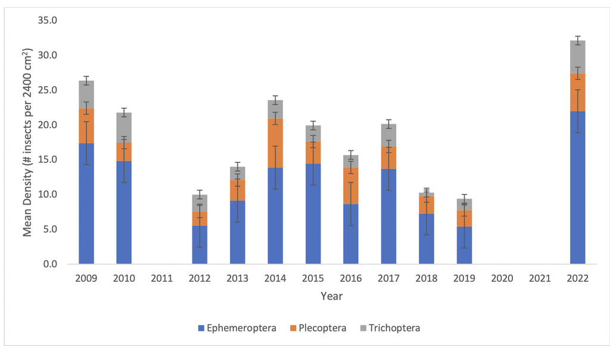

Figure 1. Mean densities of Ephemeroptera, Plecoptera, and Trichoptera between 2009 and 2022 in Middlebury and New Haven stream research sites in Vermont. Error bars are ±SE.No samples were collected in 2011, 2020, or 2021.

**My process to recreate Figure 1:**

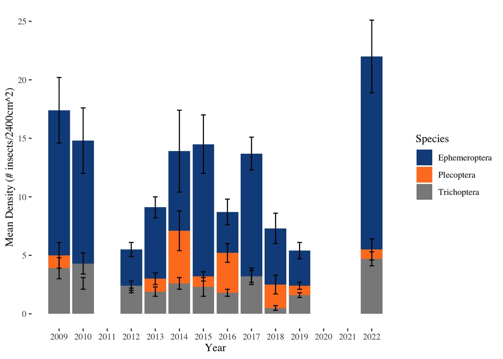

```r
dataF1 <- read.table("BIO1007A_Data/finalData.csv", header=TRUE, sep=",", stringsAsFactors = T)
SE <- std.error(dataF1[2:43, -1])

plot_F1 <- ggplot(data=dataF1, aes(x=Year, y=Density, fill=Species)) +
  geom_bar(stat="identity", position="identity") +
  geom_errorbar(aes(ymin=Mean-SE, ymax=Mean+SE),width=0.2)+
  #adding error bars. Mean is from mean insect density and SE was calculated in excel and put into a separate column to make it easier to plot
  scale_fill_manual(values=c("dodgerblue4","chocolate1", "grey54")) +
  scale_x_continuous(breaks=seq(2009,2022, by=1)) +
  scale_y_continuous(breaks=seq(0,30, by=5)) +
  ylab("Mean Density (# insects/2400cm^2)") +
  theme_tufte()
 # theme(legend.postion="bottom")
plot_F1
```

**Orignal Figure 2 :**

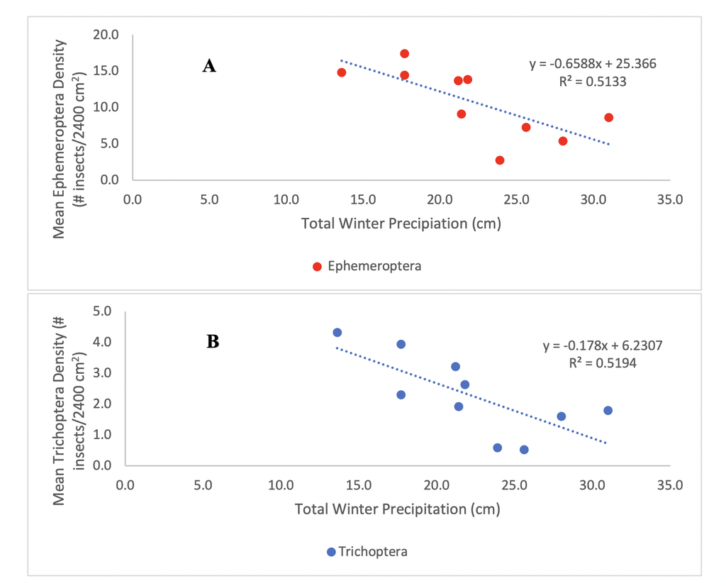

Figure 2. Effects of winter precipitation on Ephemeroptera (A) and Trichoptera (B) densities between 2009 and 2022 in Middlebury and New Haven stream research sites in Vermont.